# Project 2 : Data Wrangling

Heidi, Harriet, Viola

Github Repository [^1]

```r
# Loading datasets ----
load("house_elections.rda")
load("candidates.rda")
load("committees.rda")
load("contributions.rda")
```

```r
# Verification of the data ----
glimpse(house_elections)
glimpse(candidates)
glimpse(committees)
glimpse(contributions)
```

```r
# Modifying the candidates data frame ----
candidates_NY2012 <- candidates %>%
  filter(cand_office_state == "NY")%>%
  filter(cand_party_affiliation == "DEM")%>%
  filter(cand_party_affiliation == "DEM") %>%
  filter(cand_election_yr == 2012) %>%
  select(cand_id,
         cand_name)
```

```r
# Creating a table of candidate IDs from the wrangled candidates data set ----
cand_IDs <- select(candidates_NY2012,
                   matches("cand_id"))
```

```r
# Wrangling the contributions data frame ----
contributions_NY <- contributions %>%
  filter(cand_id %in% cand_IDs$cand_id) %>%
  select(cand_id,
         transaction_amt)
```

```r
# Wrangling the house elections data frame ----
house_elections_NY2012 <- house_elections %>%
  select(fec_id,
         ge_winner,
         incumbent)
```

```r
# Joining the wrangled contributions and candidates data frames using full_join ----
contr_cand_joined <- full_join(contributions_NY,
                               candidates_NY2012,
                               by= "cand_id") %>%
  group_by(cand_id,
           cand_name) %>%
  summarise(sum = sum(transaction_amt)) %>%
  arrange(sum)
```

```r
# Wrangling house elections by filtering with candidates IDs in the joined candidate and contribution data frame ----
house_elections_NY2012 <- filter(house_elections_NY2012,
                                 fec_id %in% contr_cand_joined$cand_id) %>%
  mutate(cand_id = fec_id)
```

```r
# Creating the final data frame by using inner join to join the wrangled house election and the previously joined data frame of candidates and contributions ----
final_df <- inner_join(contr_cand_joined,
                       house_elections_NY2012,
                       by = "cand_id") %>%
  select(cand_name,
         sum,
         ge_winner,
         incumbent) %>%
  arrange(sum) %>%
  filter(sum >= 50000) %>% # we chose to filter out candidates who received less than 50 000 dollars^[http://www.msnbc.com/hardball/how-much-does-it-cost-win-seat-congre]
  filter(!is.na(sum))
```

```r
options(scipen = 100000)
NYDemplot1 <- ggplot(data = final_df,
                   aes(x = reorder(cand_name,-sum),
                       y = sum, fill = ge_winner)) +
  geom_bar(position = "dodge",
           stat = "identity") +
  coord_flip() +
  ggtitle("Do Contributions Determine House-Election success?") +
  xlab("") +
  labs(fill="") +
  scale_fill_discrete(labels=c("Lost", "Won")) +
  scale_y_continuous(name = "Money Contributed (USD)",
                     breaks=c(0,2000000,4000000),
                     labels=c("0",
                              "2,000,000",
                              "4,000,000")) +
  theme(axis.text.x = element_text(angle = 0))
```

```r
# Editing the faceted graph incumbent label ----
incumbent <- c("Non incumbent", "Incumbent")
names(incumbent)<-c("FALSE","TRUE")
```

```r
# Faceting the final data graphic by incumbent ----
NYDemplot2 <- ggplot(data = final_df,
                   aes(x = reorder(cand_name,-sum),
                       y = sum,
                       fill = ge_winner)) +
  geom_bar(position = "dodge",
           stat = "identity")+
  coord_flip() +
  ggtitle("Do Contributions Determine House-Election success?") +
  xlab("") +
  labs(fill="") +
  scale_fill_discrete(labels = c("Lost","Won")) +
  scale_y_continuous(
    name = "Money Contributed (USD)",
    breaks=c(0,2000000,4000000),
    labels=c("0", "2,000,000", "4,000,000")) +
  facet_wrap(~incumbent,labeller = labeller(incumbent = incumbent))+
   theme_get()
```

# Functions

Functions to generalize our wrangling

```r
# Function 1 generalizes the data wrangling for the candidates dataset ----
function1_candidates <- function(year, state,party) {
  candidates %>%
    filter(cand_election_yr == year) %>%
    filter(cand_party_affiliation == party) %>%
    filter(cand_office_state == state) %>%
    select(cand_id, cand_name)
}
```

```r
# Function 2 takes the data frame made by the 1st function and creates a list of the candidate IDs from that data frame ----
function2_candid_id <- function(function1df) {
  select(function1df, matches("cand_id"))
}
```

```r
# Function 3 takes the data frame made from function 2 and uses it to wrangle the contributions data frame ----
function3_contributions <- function(function2df) {
  contributions %>%
    filter(cand_id %in%
             function2df$cand_id) %>%
    select(cand_id, transaction_amt)
}
```

```r
# Function 4 takes the wrangled candidates data frame produced by function 1 and the wrangled contribution data frame produced by function 3 and joins those two dataframes ----
function4_joincand_cont <- function(function1df, function3df) {
  full_join(function1df, function3df, by="cand_id") %>%
    group_by(cand_id, cand_name) %>%
    summarise(sum=sum(transaction_amt)) %>%
    arrange(sum)
}
```

```r
# Function 5 takes the data frame created by function 4, and uses it to wrangle the house elections data frame ----
function5_house_elec <- function(function4df) {
  house_elections %>%
    select(fec_id, ge_winner, incumbent) %>%
    filter(fec_id %in% function4df$cand_id) %>%
    mutate(cand_id = fec_id)
}
```

```r
# Function 6 takes the data frame created by function 4 and function 5 and joins them to create the final data frame that will produce the overall analysis

function6_finaldf <- function(function4df, function5df) {
  inner_join(function4df, function5df, by = "cand_id") %>%
    select(cand_name, sum, ge_winner, incumbent) %>%
    arrange(ge_winner) %>%
    filter(!is.na(sum)) %>%
    filter(sum > 50000)
}
```

```r
# Function 7 creates a plot of the wrangled data created in function 6 ----
function7_plot <- function(function6df) {
      ggplot(data = function6df,
                       aes(x = reorder(cand_name,-sum),
                           y = sum,
                           fill = ge_winner)) +
      geom_bar(position = "dodge",
               stat = "identity") +
                         coord_flip() +
  ggtitle("Do Contributions Determine House-Election success?") +
  xlab("") +
  labs(fill="") +
  scale_fill_discrete(labels=c("Lost", "Won")) +
  scale_y_continuous(name = "Money Contributed (USD)",
                     breaks=c(0,2000000,4000000),
                     labels=c("0",
                              "2,000,000",
                              "4,000,000")) +
  theme(axis.text.x = element_text(angle = 0))
}
```

```r
# Function 8 adds further analysis to the plot created by function 7 ----
function8_facet <- function(function7plotname) {
  function7plotname + facet_wrap(~incumbent,labeller = labeller(incumbent = incumbent))+
   theme_get()
}
```

```r
# Generalizing our analysis for New York Republicans ----
NYR <- function1_candidates(2012, "NY", "REP")
NYRcandid <- function2_candid_id(NYR)
NYRcontr <- function3_contributions(NYRcandid)
NYRjoined <- function4_joincand_cont(NYR, NYRcontr)
NYRhouse <- function5_house_elec(NYRjoined)
NYRfinal <- function6_finaldf(NYRjoined, NYRhouse)
NYRepplot1 <- function7_plot(NYRfinal)
NYRepplot2 <- function8_facet(NYRepplot1)
```

```r
# Generalizing our analysis for California Democrats ----
CAD <- function1_candidates(2012, "CA", "DEM" )
CADcandid <- function2_candid_id(CAD)
CADcontr <- function3_contributions(CADcandid)
CADjoined <- function4_joincand_cont(CAD, CADcontr)
CADhouse <- function5_house_elec(CADjoined)
CADfinal <- function6_finaldf(CADjoined, CADhouse)
CADemplot1 <- function7_plot(CADfinal)
CADemplot2 <- function8_facet(CADemplot1)
```

```r
# Generalizing our analysis for California Republicans ----
CAR <- function1_candidates(2012, "CA", "REP" )
CARcandid <- function2_candid_id(CAR)
CARcontr <- function3_contributions(CARcandid)
CARjoined <- function4_joincand_cont(CAR, CARcontr)
CARhouse <- function5_house_elec(CARjoined)
CARfinal <- function6_finaldf(CARjoined, CARhouse)
CARepplot1 <- function7_plot(CARfinal)
CARepplot2 <- function8_facet(CARepplot1)
```

```r
# Generalizing our analysis for Texas Democrats ----
TXD <- function1_candidates(2012, "TX", "DEM" )
TXDcandid <- function2_candid_id(TXD)
TXDcontr <- function3_contributions(TXDcandid)
TXDjoined <- function4_joincand_cont(TXD, TXDcontr)
TXDhouse <- function5_house_elec(TXDjoined)
TXDfinal <- function6_finaldf(TXDjoined, TXDhouse)
TXDemplot1 <- function7_plot(TXDfinal)
TXDemplot2 <- function8_facet(TXDemplot1)
```

```r
# Generalizing our analysis for Texas Republicans ----
TXR <- function1_candidates(2012, "TX", "REP" )
TXRcandid <- function2_candid_id(TXR)
TXRcontr <- function3_contributions(TXRcandid)
TXRjoined <- function4_joincand_cont(TXR, TXRcontr)
TXRhouse <- function5_house_elec(TXRjoined)
TXRfinal <- function6_finaldf(TXRjoined, TXRhouse)
TXRepplot1 <- function7_plot(TXRfinal)
TXRepplot2 <- function8_facet(TXRepplot1)
```

#### New York

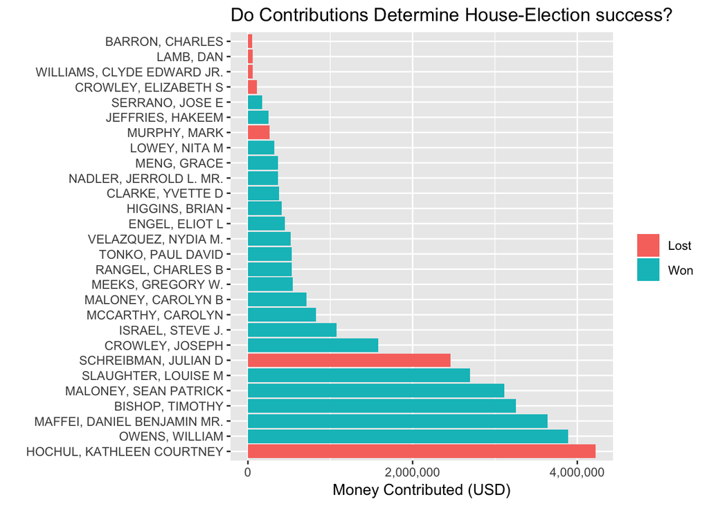

```r
# The plots for New York ----
NYDemplot1
```

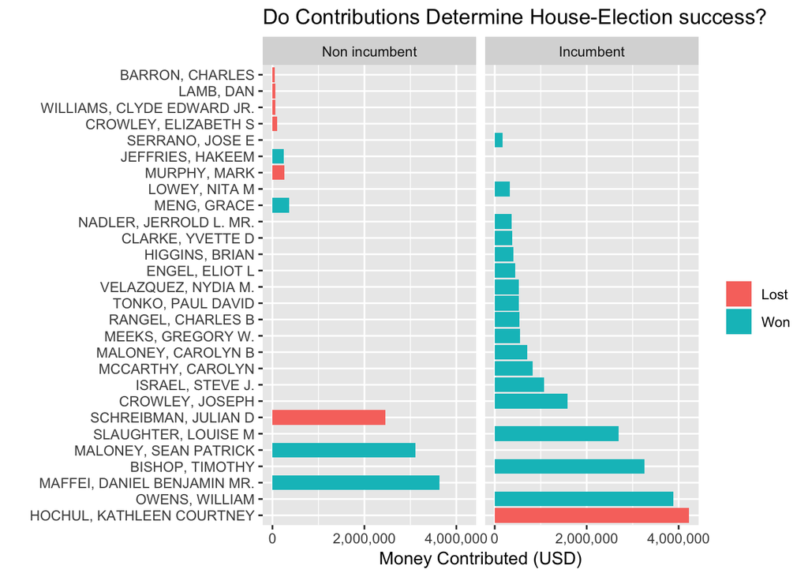

```r
NYDemplot2
```

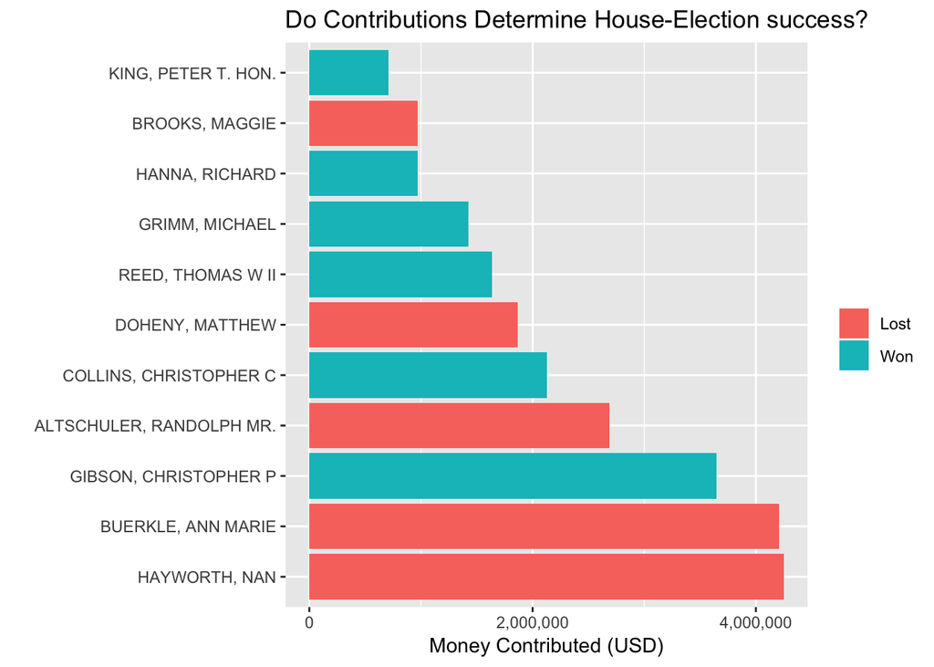

```r
NYRepplot1
```

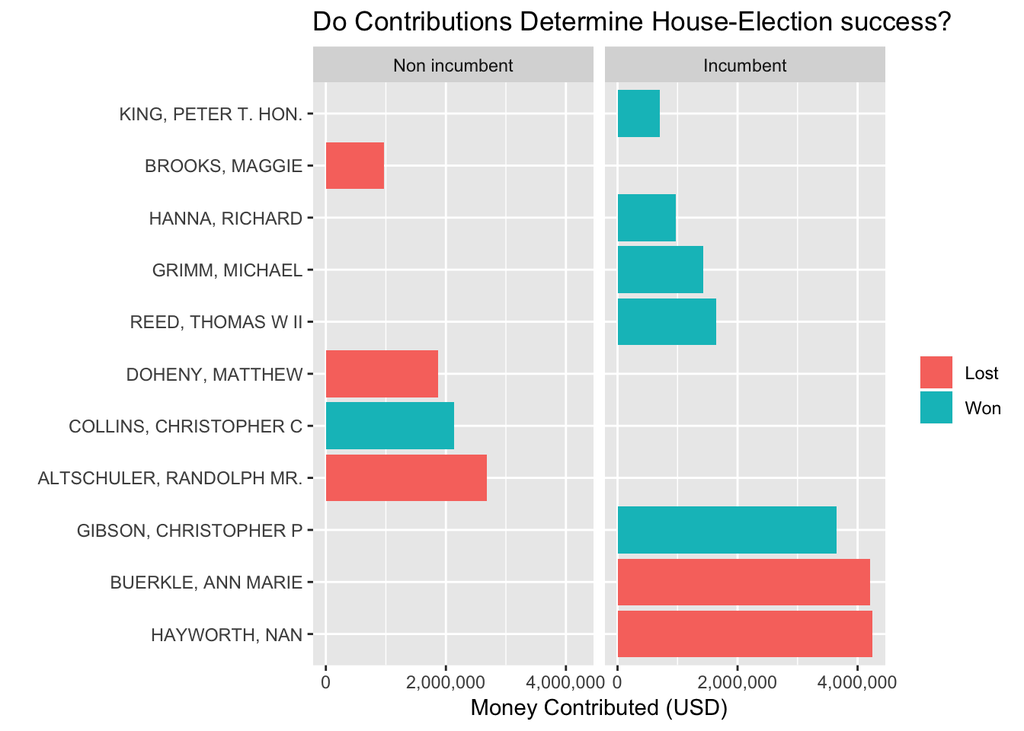

```r
NYRepplot2
```

### California

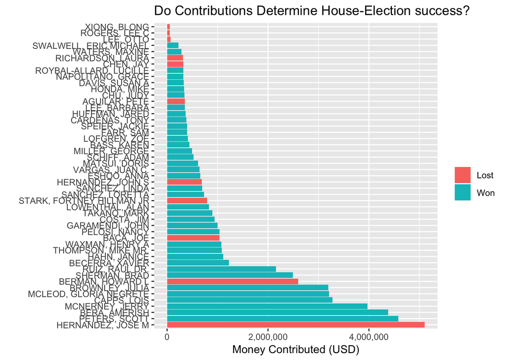

```r
# The plots for California ----
CADemplot1
```

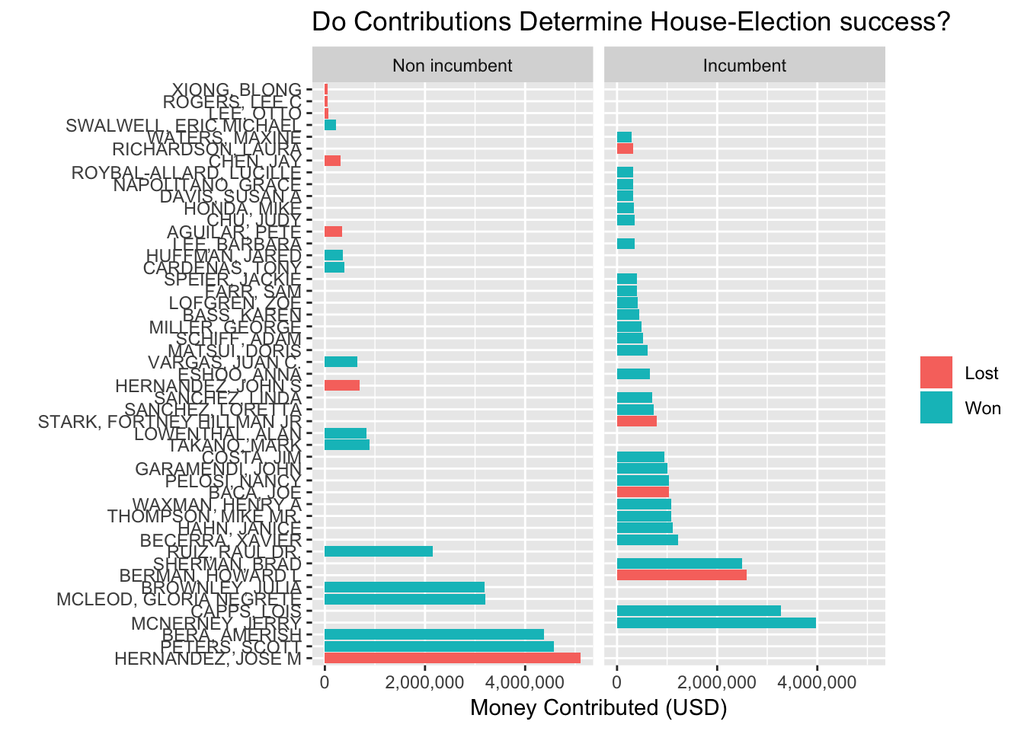

```r
CADemplot2
```

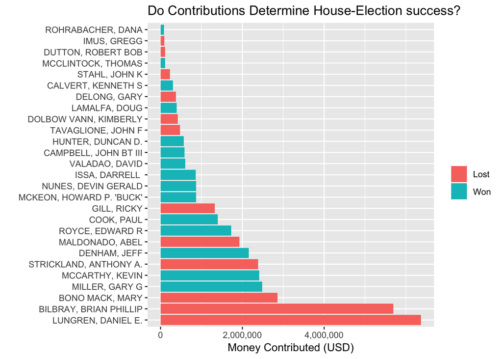

```r
CARepplot1
```

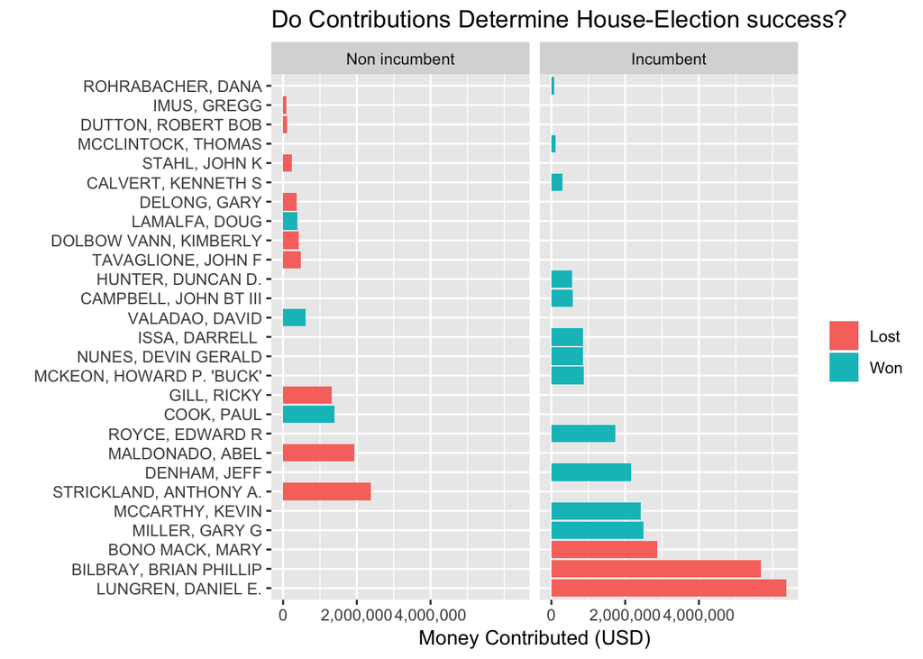

```r
CARepplot2
```

### Texas

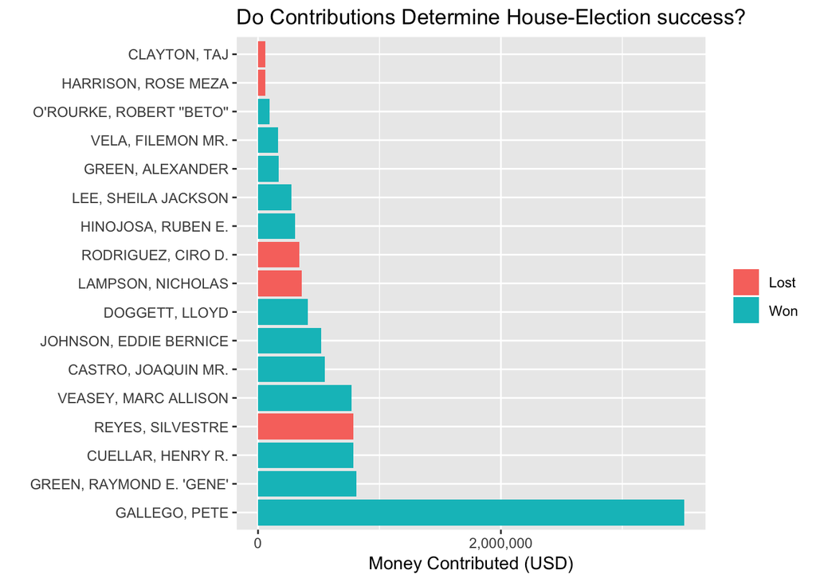

```r
# The plots for Texas ----
TXDemplot1
```

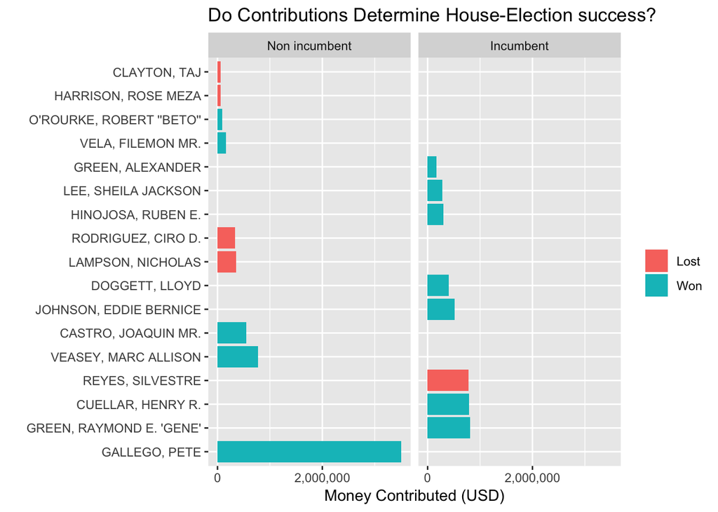

```r
TXDemplot2
```

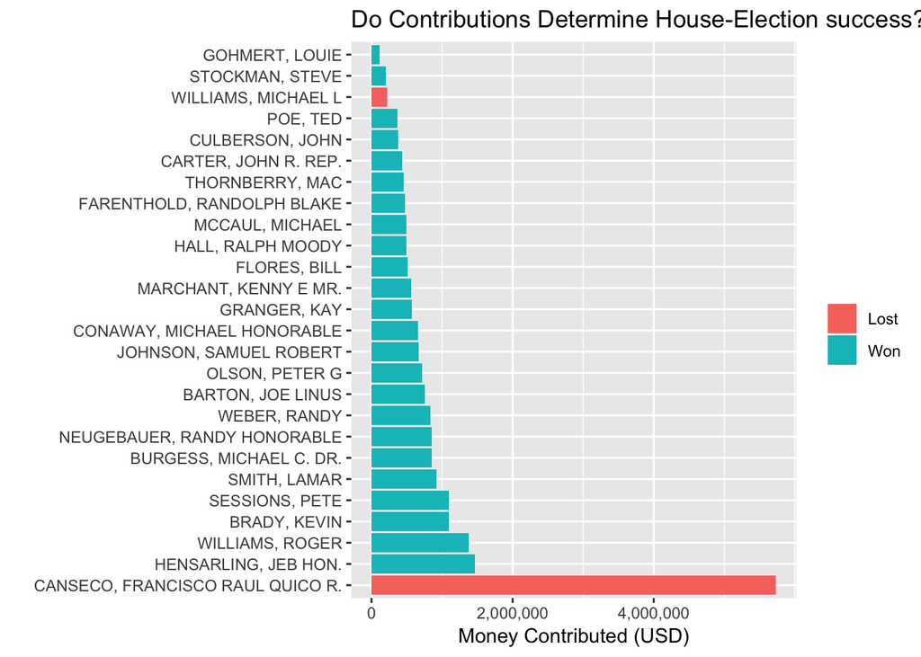

```r
TXRepplot1
```

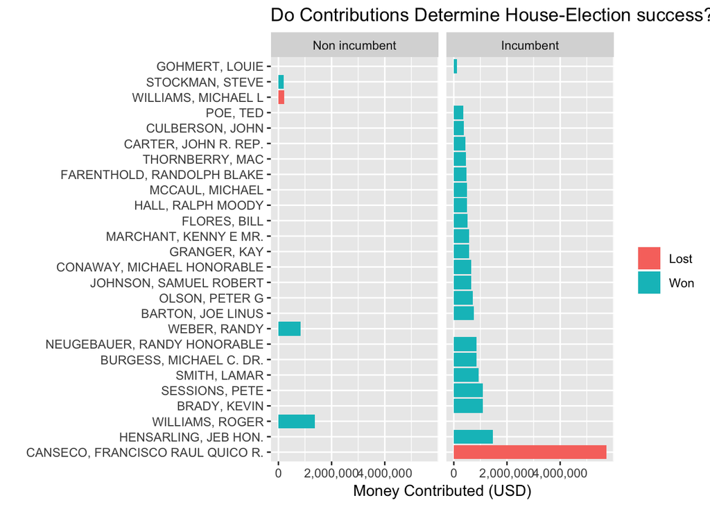

```r
TXRepplot2
```

## Analysis

*The question our wrangled data attempts to address is whether the total amount of contributions received by candidates running in house elections is positively correlated with their chances of a win. We analyzed data in the year 2012 from three FEC data sets: Candidates, Contributions and House Elections.*

**Context**

The House of Representatives is composed of politicians who represent their congressional districts in their respective states. The number of congressional districts allocated to each of the 50 states is based on the state’s population size. Each district is entitled to one representative, and there are multiple districts in each state. Thus, there will be multiple candidates running for house election within each party for a particular state. Our analysis focuses on these candidates running for election to The House of Representatives.

**Method of investigation**

Our analysis took part in 4 stages:

1. We focused on candidates within a particular state, year and party. Party is included as variable to control for the effect of whether a state is already ‘blue’ or ‘red’ from the last election cycle. We selected New York Democrats in 2012 and wrangled this from the FEC “Candidates” data set.
2. We created a list of the candidates’ IDs from our wrangled candidates data set, and used these IDs to filter out corresponding contributions from the FEC “contributions” data set. The two datasets, “Candidates” and “Contributions”, were joined by matching candidate IDs.
3. In the House Elections dataset, we filtered for our variables of interest: candidate ID (under the name fec_id), whether candidate won or lost, and whether they were an incumbent (this choice will become clear in our analysis). The House Election dataset was then filtered according to the earlier wrangled candidate IDs, which in our particular case was the candidate IDs of New York Democrats in 2012.
4. The final data frame was created by joining the data sets; Contributions, Candidates and House Elections by candidate ID. The total amount of contributions to each candidate was calculated. Candidates with no data were omitted.

According to previous research[^2], the average amount that house candidates received in donations in 2012 was approximately 1.6 million dollars. Therefore, we filtered out candidates who received less than $50000. This gives us a diversity of candidates and eliminates any data that may not be useful in our analysis.

Considering that our sample size becomes too small to conclude any trend once we wrangled for year, party and state, we created functions to generalize our analysis for more states. Since a greater number of candidates run in states with large populations, we chose the three most populated states in each region: New York (East), California (West) and Texas (South).

**Results**

In our initial analysis, the graphs that do not take into account whether a candidate is an incumbent or not, we noticed that there was no consistent trend between contribution amount and wins. For example, in NY democrats (NYDemplot1), Hochul received the greatest amount in donations yet did not win. Similarly, for NY republicans (NYRepplot1), Buerkle and Hayworth got the greatest amount in contribution yet lost. We see this same result in California democrats and republicans (CADemplot1/Repplot1) and Texas republicans. There are also candidates who received relatively little in donations (less than 2 million) and still won. Thus, there seems to be no obvious direct correlation between amount of donations received and probability of winning.

**Conclusion**

From this data, we learn that if you are an incumbent, the amount of donations you receive does not necessarily have a significant impact on whether you win or not, however, if you are not an incumbent, donations matter may matter more to your success. Our analysis should be run for more states in order to strenghten this statement.

[^1]: https://github.com/tsa-heidi/sds192-mp2
[^2]: http://www.msnbc.com/hardball/how-much-does-it-cost-win-seat-congre